**Sulaiman Mathew-Wilson**  
**003133656**  
**Intro to Data Science**  
**Dr. Nerolu**  
**3 December 2025**

# A Comprehensive Look into the State of Air Pollution Globally

## Dataset sourced from Kagle:

https://www.kaggle.com/datasets/hasibalmuzdadid/global-air-pollution-dataset/code  
This project explores a variety of global air quality metrics to identify pollution trends, analyze environmental health risks, and derive actionable insights using Python-based data science tools.

```python
# Data Understanding and Cleaning
import numpy as np
import pandas as pd
import matplotlib.pyplot as plt
import seaborn as sns
import plotly.express as px
df = pd.read_csv("global_air_pollution_dataset.csv")
print(df)
```

```
                        Country              City  AQI Value AQI Category  \
0            Russian Federation        Praskoveya         51     Moderate
1                        Brazil  Presidente Dutra         41         Good
2                         Italy   Priolo Gargallo         66     Moderate
3                        Poland         Przasnysz         34         Good
4                        France          Punaauia         22         Good
...                         ...               ...        ...          ...
23458                     India      Gursahaiganj        184    Unhealthy
23459                    France            Sceaux         50         Good
23460                     India          Mormugao         50         Good
23461  United States of America       Westerville         71     Moderate
23462                  Malaysia            Marang         70     Moderate

       CO AQI Value CO AQI Category  Ozone AQI Value Ozone AQI Category  \
0                 1            Good               36               Good
```

[output cut: 25 more lines]

```python
print(df.shape)
```

```
(23463, 12)
```

```python
df.info()
```

```
<class 'pandas.core.frame.DataFrame'>
RangeIndex: 23463 entries, 0 to 23462
Data columns (total 12 columns):
 #   Column              Non-Null Count  Dtype
---  ------              --------------  -----
 0   Country             23036 non-null  object
 1   City                23462 non-null  object
 2   AQI Value           23463 non-null  int64
 3   AQI Category        23463 non-null  object
 4   CO AQI Value        23463 non-null  int64
 5   CO AQI Category     23463 non-null  object
 6   Ozone AQI Value     23463 non-null  int64
 7   Ozone AQI Category  23463 non-null  object
 8   NO2 AQI Value       23463 non-null  int64
 9   NO2 AQI Category    23463 non-null  object
 10  PM2.5 AQI Value     23463 non-null  int64
 11  PM2.5 AQI Category  23463 non-null  object
dtypes: int64(5), object(7)
memory usage: 2.1+ MB
```

```python
summary = df.describe()
print(summary)
```

```
          AQI Value  CO AQI Value  Ozone AQI Value  NO2 AQI Value  \
count  23463.000000  23463.000000     23463.000000   23463.000000
mean      72.010868      1.368367        35.193709       3.063334
std       56.055220      1.832064        28.098723       5.254108
min        6.000000      0.000000         0.000000       0.000000
25%       39.000000      1.000000        21.000000       0.000000
50%       55.000000      1.000000        31.000000       1.000000
75%       79.000000      1.000000        40.000000       4.000000
max      500.000000    133.000000       235.000000      91.000000

       PM2.5 AQI Value
count     23463.000000
mean         68.519755
std          54.796443
min           0.000000
25%          35.000000
50%          54.000000
75%          79.000000
max         500.000000
```

```python
# Replace missing values in 'Country' with 'Unknown'
df['Country'].fillna('Unknown', inplace=True)
print("Missing values in 'Country' replaced with 'Unknown'.")
```

```
Missing values in 'Country' replaced with 'Unknown'.
```

#### For 'Country', missing values were replaced with 'Unknown' because it ensures that the dataset remains usable while preventing errors in analyses that require complete geographic information

```python
# Drop rows where 'City' is missing
initial_rows = df.shape[0]
df.dropna(subset=['City'], inplace=True)
dropped_rows = initial_rows - df.shape[0]
```

#### For 'City', dropping rows was chosen because location is essential for geographical analysis, and missing city names cannot be reliably imputed.

```python
# Check datatypes of AQI columns
aqi_columns = ['AQI Value', 'CO AQI Value', 'Ozone AQI Value', 'NO2 AQI Value', 'PM2.5 AQI Value']
existing_columns = [col for col in aqi_columns if col in df.columns]
for col in existing_columns:
    if df[col].dtype != 'int64' and df[col].dtype != 'float64':
        df[col] = pd.to_numeric(df[col], errors='coerce')
        print(f"Converted '{col}' to numeric.")
print("All existing AQI columns are now numeric.")
```

```
All existing AQI columns are now numeric.
```

```python
# Renaming Long Column Headers for Clarity
rename_dict = {
    'CO AQI Value': 'CO',
    'Ozone AQI Value': 'Ozone',
    'NO2 AQI Value': 'NO2',
    'PM2.5 AQI Value': 'PM2.5'
}
df.rename(columns=rename_dict, inplace=True)
print("Renamed pollutant columns for clarity.")
```

```
Renamed pollutant columns for clarity.
```

#### Cleaned and standardized column names to make the analysis and visualizations easier to interpret.

```python
# Checking for Duplicates
duplicates = df.duplicated().sum()
print(f"Number of duplicate rows found: {duplicates}")
if duplicates > 0:
    df.drop_duplicates(inplace=True)
    print("Duplicate rows removed.")
else:
    print("No duplicates found.")
```

```
Number of duplicate rows found: 0
No duplicates found.
```

#### Checked for duplicates to avoid skewing statistics.

```python
# Ensuring all AQI columns are numeric and ready for analysis
for col in ['AQI Value', 'CO', 'Ozone', 'NO2', 'PM2.5']:
    if col in df.columns:
        negative_count = (df[col] < 0).sum()
        if negative_count > 0:
            print(f"Found {negative_count} negative values in '{col}'. Replacing with NaN.")
            df[col] = df[col].mask(df[col] < 0, np.nan)
```

```python
# Checking for outliers
def count_outliers(series):
    Q1 = series.quantile(0.25)
    Q3 = series.quantile(0.75)
    IQR = Q3 - Q1
    lower = Q1 - 1.5 * IQR
    upper = Q3 + 1.5 * IQR
    return ((series < lower) | (series > upper)).sum()
for col in ['AQI Value', 'CO', 'Ozone', 'NO2', 'PM2.5']:
    if col in df.columns:
        outliers = count_outliers(df[col])
        print(f"Outliers in '{col}': {outliers} (not removed, kept for analysis)")
```

```
Outliers in 'AQI Value': 2935 (not removed, kept for analysis)
Outliers in 'CO': 8596 (not removed, kept for analysis)
Outliers in 'Ozone': 1513 (not removed, kept for analysis)
Outliers in 'NO2': 1681 (not removed, kept for analysis)
Outliers in 'PM2.5': 2641 (not removed, kept for analysis)
```

```python
print(df)
```

```
                        Country              City  AQI Value AQI Category  CO  \
0            Russian Federation        Praskoveya         51     Moderate   1
1                        Brazil  Presidente Dutra         41         Good   1
2                         Italy   Priolo Gargallo         66     Moderate   1
3                        Poland         Przasnysz         34         Good   1
4                        France          Punaauia         22         Good   0
...                         ...               ...        ...          ...  ..
23458                     India      Gursahaiganj        184    Unhealthy   3
23459                    France            Sceaux         50         Good   1
23460                     India          Mormugao         50         Good   1
23461  United States of America       Westerville         71     Moderate   1
23462                  Malaysia            Marang         70     Moderate   1

      CO AQI Category  Ozone Ozone AQI Category  NO2 NO2 AQI Category  PM2.5  \
0                Good     36               Good    0             Good     51
```

[output cut: 25 more lines]

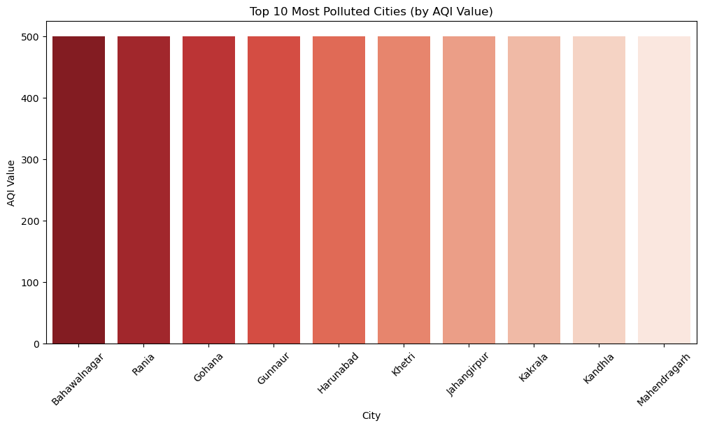

```python
top10 = df.nlargest(10, "AQI Value")

plt.figure(figsize=(12,6))
sns.barplot(data=top10, x="City", y="AQI Value", palette="Reds_r")
plt.xticks(rotation=45)
plt.title("Top 10 Most Polluted Cities (by AQI Value)")
plt.show()
```

#### The cities with the highest AQI values are shown. These represent areas with the worst air quality. High AQI values often correlate with industrial activity, traffic congestion, or geographical factors that trap pollutants.

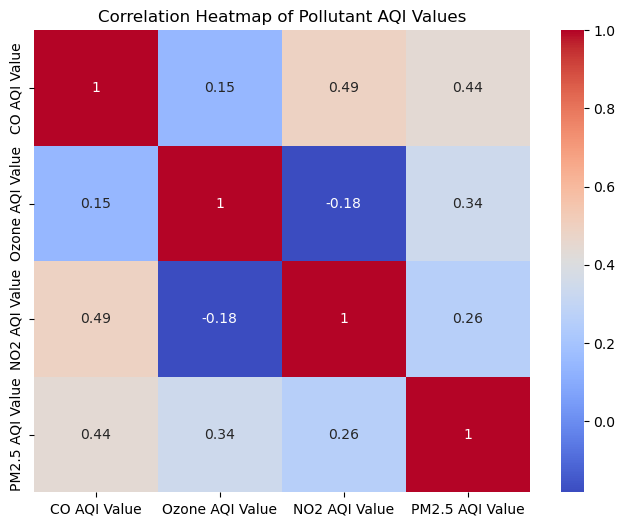

```python
# Correlation Heatmap between pollutants
pollutant_cols = [
    "CO AQI Value",
    "Ozone AQI Value",
    "NO2 AQI Value",
    "PM2.5 AQI Value"
]
plt.figure(figsize=(8,6))
sns.heatmap(df[pollutant_cols].corr(), annot=True, cmap="coolwarm")
plt.title("Correlation Heatmap of Pollutant AQI Values")
plt.show()
```

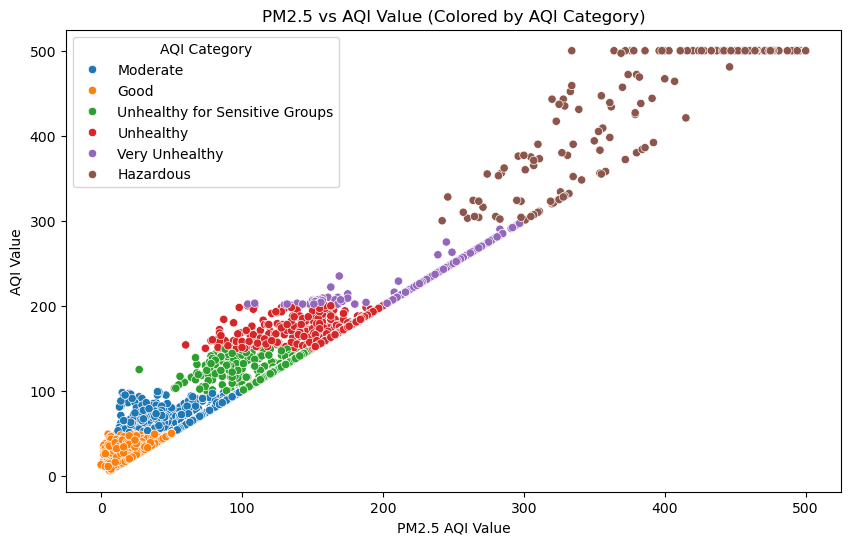

```python
# Scatter Plot: PM2.5 vs AQI
plt.figure(figsize=(10,6))
sns.scatterplot(
    data=df,
    x="PM2.5 AQI Value",
    y="AQI Value",
    hue="AQI Category"
)
plt.title("PM2.5 vs AQI Value (Colored by AQI Category)")
plt.show()
```

#### This scatter plot examines the relationship between PM2.5 and the overall AQI. A clear upward trend indicates that higher PM2.5 levels strongly influence poor AQI. Clustering by AQI category shows how PM2.5 thresholds align with health risk classifications.

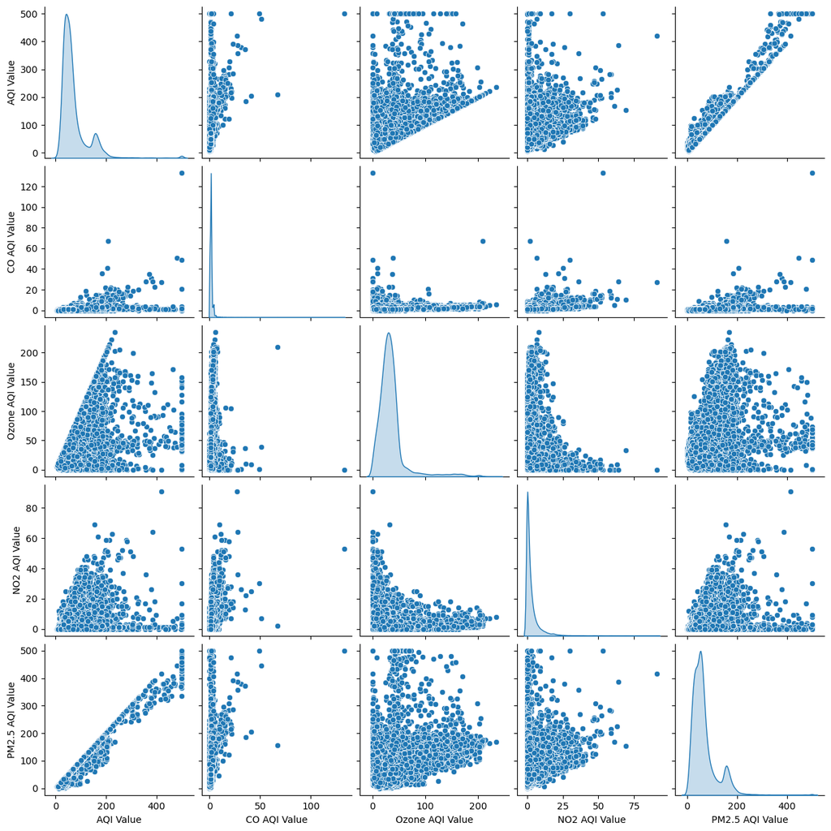

```python
# Pair Plot of Pollutants
sns.pairplot(df[[
    "AQI Value",
    "CO AQI Value",
    "Ozone AQI Value",
    "NO2 AQI Value",
    "PM2.5 AQI Value"
]], diag_kind="kde")
plt.show()
```

```python
# GeoMap (Choropleth) - Country-wise AQI Average
country_avg = df.groupby('Country')['AQI Value'].mean().reset_index()
fig = px.choropleth(
    country_avg,
    locations='Country',
    locationmode='country names',
    color='AQI Value',
    color_continuous_scale='Reds',
    title='Global Air Quality Index (AQI) by Country',
    labels={'AQI Value': 'Average AQI'}
)
fig.update_layout(
    geo=dict(
        showframe=False,
        showcoastlines=True,
        projection_type='natural earth'
    ),
    font=dict(size=14)
)
fig.show()
```

[interactive chart not shown]

#### This choropleth map visualizes average AQI values by country. Darker red shades indicate higher pollution levels. Regions in Africa, South Asia, and parts of the Middle East show elevated AQI values, suggesting systemic air quality challenges and having less of a capacity to deal with these issues.

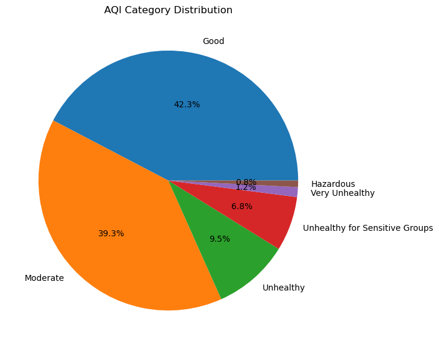

```python
# AQI Category Distribution
df["AQI Category"].value_counts().plot(
    kind="pie",
    autopct="%1.1f%%",
    figsize=(7,7)
)
plt.title("AQI Category Distribution")
plt.ylabel("")
plt.show()
```

#### This pie chart shows the proportion of cities falling into each AQI category. A high percentage in 'Moderate' or 'Unhealthy' categories indicates widespread air quality issues. The distribution helps assess the global scale of air pollution risks.

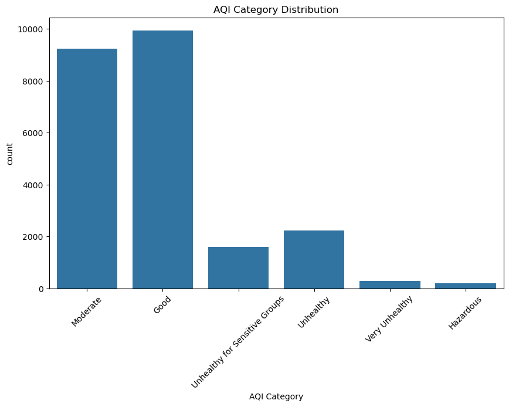

```python
# AQI Category Distribution with countplot
plt.figure(figsize=(10,6))
sns.countplot(data=df, x="AQI Category")
plt.title("AQI Category Distribution")
plt.xticks(rotation=45)
plt.show()
```

#### Shows the same information as the pie chart above, but I felt as though this visualization was valuable and worth looking at as well.